# 0 基于python语言的网络分析实践

## 4.5 网络聚类系数

聚类系数(Clustering Coefficient)：网络中与同一节点相连的节点之间也互为邻域节点的程度。  
节点聚类系数数学公式：

对于网络中的节点i，聚类系数Ci定义为与它相邻的节点间也存在连接的平均概率。假设节点i的度为ki，也即节点i所连接的邻居个数；Ei表示ki个邻居之间实际存在的边数；ki个邻居之间可能存在边的数目上限0.5ki(ki-1)。

节点的聚类系数在社交网络中有直观的含义，通俗地讲，聚类系数定量刻画你的任意两个朋友之间也互相为朋友的概率，反映的是你的朋友圈的紧密程度。

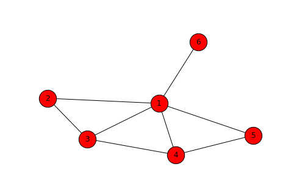

```python
G = nx.Graph()
G.add_nodes_from([1,2,3,4,5,6])
G.add_edges_from([(1,2),(1,3),(1,4),(1,5),(1,6),(2,3),(3,4),(4,5)])
pos = nx.spring_layout(G)
nx.draw(G,pos,with_labels=True,node_size = 800)
```

```python
#计算网络中每个节点的聚类系数
C_all=nx.clustering(G)
print C_all
```

```
{1: 0.3, 2: 1.0, 3: 0.6666666666666666, 4: 0.6666666666666666, 5: 1.0, 6: 0.0}
```

```python
#计算网络平均聚类系数
Average_C=nx.average_clustering(G)
print Average_C
```

```
0.605555555556
```

## 4.6 网络的度匹配系数

同配性(Assortativity)： 功能：反映的是网络中度相近节点间相互关联的程度。

度相关性：表示一个节点的度与其邻居节点度之间的相关性。

同配：网络中度大(小)的节点倾向于连接度大(小)的节点，则该网络是正相关的； 异配：网络中度大(小)的节点倾向于连接度小(大)的节点，则该网络是负相关的；

同配系数(Pearson Coefficient----皮尔森系数)： 功能：评价网络中一个节点的度与其相邻节点的度之间的关系 计算公式：

式中，ji和ki分别代表第i条边连接的两个节点的度；M表示网络中的总边数。 r取值大于0，网络中互相邻接的节点之间，其度是正相关的，即度大的节点倾向于连接度大的节点，而度小的节点倾向于连接度小的节点，这样的网络具有同配性，对应的相关性系数称为同配系数。

同配系数r取值范围：0<=|r|<=1

- (1) 当r<0时，网络是异配的；
- (2) 当r>0时，网络是同配的；
- (3) 当r=0时，网络是不相关的，即网络中一个节点的度与其邻居节点度之间没有相关性，如随机网络。

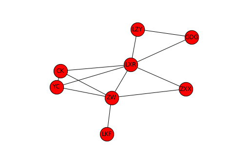

```python
#生成自定义网络G
G = nx.Graph()
G.add_nodes_from(['CK','YC','ZXX','GDG',
                  'ZW','LXR','LKF','LZY'])
G.add_edges_from([('LKF','ZW'),('ZW','YC'),
                  ('ZW','CK'),('ZW','ZXX'),
                  ('CK','YC'),('CK','LXR'),
                  ('LXR','YC'),('LXR','ZXX'),
                  ('LXR','LZY'),('LXR','GDG'),
                  ('LZY','GDG'),('ZW','LXR')])
pos = nx.spring_layout(G)
nx.draw(G,pos,with_labels=True,node_size = 800)
```

```python
#计算网络的匹配系数
r_G=nx.degree_assortativity_coefficient(G)
print r_G
```

```
-0.485148514851
```

结论：该网络的同配系数r<0，说明该网络为异配网络。  
现实生活中由于个人所处社会阶级的限制，通常只能够跟与自己在同一阶层的人社交，精英人物之间更容易结识，而普通人只能认识与自己相似的人。在线社交网络打破了这一社交阶层的制约，普通人更容易与精英人物建立单向关注关系或相识关系。因此，在社交网络通常具有异配性，或表现出不明显的同配性。

## 4.7 网络中节点的重要性

很多复杂网络呈现出异质的拓扑结构，这说明这些网络中每个节点的重要程度是不同的。在复杂网络的各种基础研究工作中，识别出网络中的一些最重要节点具有非常明显的实用价值。对于各种各样的实证网络，识别出重要节点可以针对性地分析其性质，制定正确的策略和措施。如在恐怖组织关系网络中，如果能定位出组织中的头目和骨干分子，那么就能迅速侦察到恐怖集团的破坏行动；在大规模计算机网络中，可以根据服务器节点的重要程度进行有针对性的备份，这样既能保证网络的鲁棒性，也能有效地节省资源；在传染病传播的社交网络中，如果能尽快找出超级传染者，就可以有针对性地治疗和隔离重点病人，有效防止病毒的传播和扩散。为满足应用的需求就需要设计和计算各种有针对性的中心化指标，不同类型的复杂网络通常也需要使用不同的中心化指标来进行度量和刻画。目前最常用的衡量节点重要性的中心化指标为度中心性指标、紧密度中心性指标和介数中心性指标

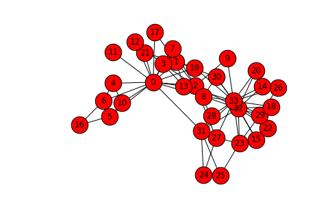

```python
# 连边对数据可以直接读取来生成网络
G = nx.read_edgelist("karate.txt")
G = Gn_karate.to_undirected()
pos=nx.spring_layout(G)
nx.draw(G,pos,with_labels=True,node_size=600)
```

### 4.7.1 度中心性 (Degree Centrality)

节点度就是所有和它直接相连的节点数量，是研究网络拓扑结构的最基本参数。节点的度值体现了该节点和周围节点之间建立直接联系的能力，因此节点的度值中心性大小体现了节点的活跃特性，中心性较高的节点具有较多的连接关系。设网络中有个节点，则节点的度指标计算公式为

[figure not shown]

其中，

[figure not shown]

表示节点直接相连的节点数，也就是该节点的度值。

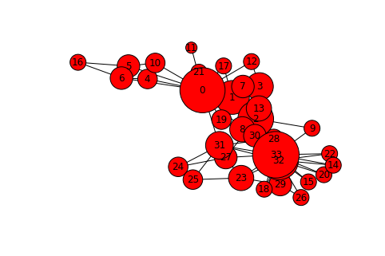

```python
#求节点的度
degree_G=G.degree()

#取出键值
degree_values=degree_G.values()
#取键形成新的列表
degree_keys=degree_G.keys()

pos=nx.spring_layout(G)
nx.draw(G,pos,with_labels=True,nodelist=degree_keys,node_size=[x*200 for x in degree_values])
```

### 4.7.2 紧密度中心性 (Closeness Centrality)

节点中心性的第二种观点是建立在紧密度概念的基础上，度量方法强调在所有节点的集合中，某一个节点与所有其他节点之间的接近程度。从接近程度的角度看，占据中心的节点在与其他节点之间交流信息时比较有效率。紧密度中心性刻画网络中节点到达网络中其它节点的难易程度, 其值定义为该节点到达所有其它节点的最短距离之和的倒数。设网络中有个节点，则节点的紧密度中心性计算公式为

[figure not shown]

其中，

[figure not shown]

是节点和之间的最短路径。度中心性指标反映了一个节点对于网络中其他节点的直接影响力，而紧密度中心性指标则反映的是节点通过网络对其他节点施加影响的能力，因而紧密度指标相对于度指标更加能反映网络全局的结构。

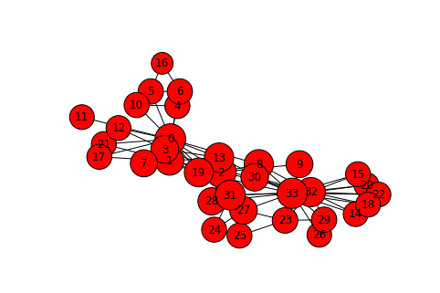

```python
closeness_G=nx.closeness_centrality(G)
#取出键值
closeness_values=closeness_G.values()
#取键形成新的列表
closeness_keys=closeness_G.keys()

pos=nx.spring_layout(G)
nx.draw(G,pos,with_labels=True,nodelist=closeness_keys,node_size=[x*2000 for x in closeness_values])
```

### 4.7.3 介数中心性 (Betweenness Centrality)

介数中心性是建立在以下假设的基础上，即一个节点如果能够控制传播通道的话，则它在网络中应该获得更大的权利、具有较高的重要性。两个不相邻节点之间的相互作用依赖于网络中的其他节点，特别是那些在这两个节点之间提供连接路径的节点，因此可认为重要节点在某种程度上控制着很多不相邻节点之间的相互作用，这就是介数中心性的物理意义。介数指标刻画了网络中节点对于信息流动的影响力，在网络中使用最短路径路由算法，介数中心性指标刻画了信息流经给定节点的可能性，节点的介数中心性均会随着经过该节点的信息流的增大而增大，因此利用介数指标可以确定信息负载繁重的网络节点。网络中节点的介数中心性计算公式为

[figure not shown]

其中，

[figure not shown]

表示节点和之间经过节点的最短路径数。

[figure not shown]

表示节点和之间的最短路径数。介数中心性除了能衡量节点的重要性外，它的另一个重要作用是能够分辨出跨界者，即那些在两个或多个社团结构中扮演着不可或缺桥梁作用的个体。

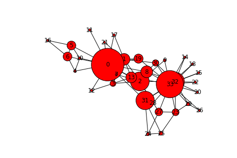

```python
betweenness_G=nx.betweenness_centrality(G)

#取出键值
betweenness_values=betweenness_G.values()
#取键形成新的列表
betweenness_keys=betweenness_G.keys()

pos=nx.spring_layout(G)
nx.draw(G,pos,with_labels=True,nodelist=betweenness_keys,node_size=[x*10000+20 for x in betweenness_values])
```

### 4.7.4 eigenvector_centrality

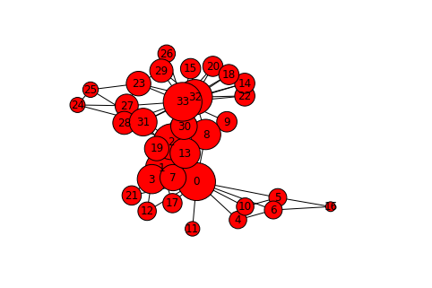

```python
eigenvector_G=nx.eigenvector_centrality_numpy(G)

#取出键值
eigenvector_values=eigenvector_G.values()
#取键形成新的列表
eigenvector_keys=eigenvector_G.keys()

pos=nx.spring_layout(G)
nx.draw(G,pos,with_labels=True,nodelist=eigenvector_keys,node_size=[x*5000 for x in eigenvector_values])
```

### 4.7.5 katz_centrality

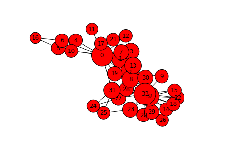

```python
katz_G=nx.katz_centrality_numpy(G)

#取出键值
katz_values=katz_G.values()
#取键形成新的列表
katz_keys=katz_G.keys()

pos=nx.spring_layout(G)
nx.draw(G,pos,with_labels=True,nodelist=katz_keys,node_size=[x*6000 for x in katz_values])
```

### 4.7.6 communicability_centrality

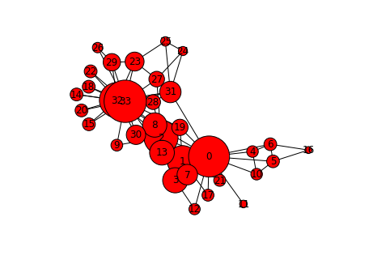

```python
communicability_G=nx.communicability_centrality(G)

#取出键值
communicability_values=communicability_G.values()
#取键形成新的列表
communicability_keys=communicability_G.keys()

pos=nx.spring_layout(G)
nx.draw(G,pos,with_labels=True,nodelist=communicability_keys,node_size=[x*20 for x in communicability_values])
```

### 4.7.7 load_centrality

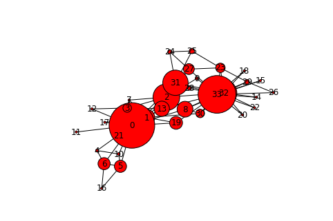

```python
load_centrality_G=nx.load_centrality(G)

#取出键值
load_centrality_values=load_centrality_G.values()
#取键形成新的列表
load_centrality_keys=load_centrality_G.keys()

pos=nx.spring_layout(G)
nx.draw(G,pos,with_labels=True,nodelist=load_centrality_keys,node_size=[x*10000+10 for x in load_centrality_values])
```

### 4.7.8 边的中心性（edge_betweenness_centrality）

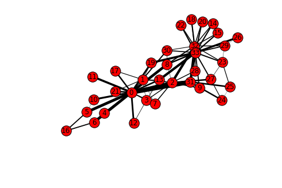

```python
edge_betweenness=nx.edge_betweenness_centrality(G)

#取出键值
edge_betweenness_values=edge_betweenness.values()
#取键形成新的列表
edge_betweenness_keys=edge_betweenness.keys()

pos=nx.spring_layout(G)
#nx.draw(G,pos,with_labels=True,nodelist=load_centrality_keys,node_size=[x*10000+10 for x in load_centrality_values])
nx.draw(G,pos,with_labels=True,edgelist=edge_betweenness_keys,width=[x*60 for x in edge_betweenness_values])
```

## 4.8 网络中的平均最短路径长度

### 4.8.1 取出网络中的连通成分

```python
G=nx.read_edgelist('edge.txt')
#如果该网络是连通的则返回True，否则返回Flase
print(nx.is_connected(G))
#打印连通成分的列表
print([len(c) for c in sorted(nx.connected_components(G), key=len, reverse=True)])
#选择最大的连通成分
Gc = max(nx.connected_component_subgraphs(G), key=len)
print(nx.is_connected(Gc))
pos=nx.spring_layout(Gc)
#绘制图表
nx.draw(Gc,pos,with_labels=False,node_size=500)
```

[output not shown]

### 4.8.2 网络的直径

nx.diameter(G)返回图G的直径（最长最短路径的长度），

### 4.8.3 节点间平均最短路径长度

而nx.average_shortest_path_length(G)则返回图G所有节点间平均最短路径长度。

# 5 社交网络的社团划分算法

## 5.1 创建环境与网络数据的读入

```python
#由于networkx中没有常用的社团划分算法，所以这里面我们使用igraph包中的社团划分算法来分析网络社团结构，但是画图还是用networkx中的画图功能
import igraph as ig                                         #导入igraph网络分析模块
```

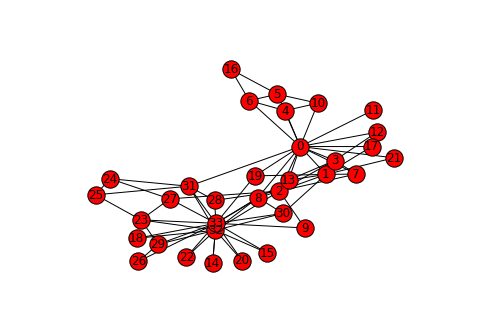

```python
# 连边对数据可以直接读取来生成网络
Gn_karate = nx.read_edgelist("karate.txt")
Gn_karate = Gn_karate.to_undirected()

#对生成的网络数据进行可视化
pos=nx.spring_layout(Gn_karate)
nx.draw(Gn_karate,pos,with_labels=True)
```

```python
#获取网络数据中的边列表，并根据其使用igraph创建网络
Gi_karate_d=ig.Graph.Read_Edgelist("karate.txt")              #基于这些连边使用igraph创建一个新网络
Gi_karate=Gi_karate_d.as_undirected()
print Gi_karate
```

```
IGRAPH U--- 34 78 --
+ edges:
 0 --  1  2  3  4  5  6  7  8 10 11 12 13 17 19 21 31
 1 --  0  2  3  7 13 17 19 21 30
 2 --  0  1  3  7  8  9 13 27 28 32
 3 --  0  1  2  7 12 13
 4 --  0  6 10
 5 --  0  6 10 16
 6 --  0  4  5 16
 7 --  0  1  2  3
 8 --  0  2 30 32 33
 9 --  2 33
10 --  0  4  5
11 --  0
12 --  0  3
```

[output cut: 21 more lines]

## 5.2 基于K派系进行社团检测

```python
community_list=list(nx.k_clique_communities(Gn_karate, 3))   # k=3
print community_list
```

```
[frozenset([u'10', u'16', u'5', u'4', u'0', u'6']), frozenset([u'22', u'26', u'19', u'12', u'15', u'21', u'13', u'27', u'20', u'14', u'17', u'23', u'33', u'32', u'31', u'30', u'28', u'29', u'1', u'0', u'3', u'2', u'7', u'18', u'8']), frozenset([u'24', u'25', u'31'])]
```

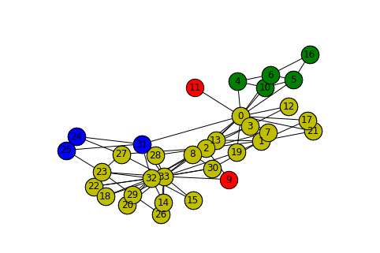

```python
#用三个不同颜色表示出三个不同的社团
nx.draw(Gn_karate,pos,with_labels=True, node_size = 500)

nx.draw_networkx_nodes(Gn_karate,pos,nodelist=community_list[0], node_size=500, node_color='g', with_labels=True)
nx.draw_networkx_nodes(Gn_karate,pos,nodelist=community_list[1], node_size=500, node_color='y', with_labels=True)
nx.draw_networkx_nodes(Gn_karate, pos,nodelist= community_list[2], node_size=500, node_color='b', with_labels=True)
```

```python
#计算社团划分对应模块度
membership=[]        #新建一个空列表，membership初始化
for i in range(0,len(Gn_karate)):
    membership.append(0)

# 根据社团划分对membership赋值
for i in range(0,len(community_list)):
    nodes=map(int, community_list[i])
    for j in nodes:
        membership[j]=i
print membership

#根据membership计算模块度
Q_modularity=ig.GraphBase.modularity(Gi_karate, membership)
print Q_modularity
```

```
[1, 1, 1, 1, 0, 0, 0, 1, 1, 0, 0, 0, 1, 1, 1, 1, 0, 1, 1, 1, 1, 1, 1, 1, 2, 2, 1, 1, 1, 1, 1, 2, 1, 1]
0.170529257068
```

## 5.3 基于fastgreedy算法的社团检测

```python
#对g1进行社团划分，并显示结果
h1=Gi_karate.community_fastgreedy(weights=None)   # fastgreedy算法社团检测
print h1
```

```
Dendrogram, 34 elements, 33 merges

18 22 15 8 30 32 24 25 31 28 26 29 33 23 27 14 20 7 3 12 9 2 13 1 17 21 19 16 5 6 0 4 10 11
|  |  |  | |  |  |  |  |  |  |  |  |  |  |  |  |  | | |  | | |  | |  |  |  |  | | | | |  |
|  |  |  | |  |  |  |  |  |  |  |  |  |  |  |  |  | | |  | | |  | |  |  |  `--' | | | |  |
|  |  |  | |  |  |  |  |  |  |  |  |  |  |  |  |  | | |  | | |  | |  |  |   |   | | | |  |
|  |  |  | |  |  |  |  |  |  |  |  |  |  |  |  |  | | |  | | |  | |  |  |   `---' | | |  |
|  |  |  | |  |  |  |  |  |  |  |  |  |  |  |  |  | | |  | | |  | |  |  |     |   | | |  |
|  |  |  | |  |  |  |  |  |  |  |  |  |  |  |  |  | | |  | | |  | |  |  |     `---' | |  |
|  |  |  | |  |  |  |  |  |  |  |  |  |  |  |  |  | | |  | | |  | |  |  |       |   | |  |
|  |  |  | |  |  |  |  |  |  |  |  |  |  |  |  |  | | |  | | |  | |  |  |       `---' |  |
|  |  |  | |  |  |  |  |  |  |  |  |  |  |  |  |  | | |  | | |  | |  |  |         |   |  |
|  |  |  | |  |  |  |  |  |  `--'  |  |  |  |  |  | | |  | | |  | |  |  |         `---'  |
|  |  |  | |  |  |  |  |  |   |    |  |  |  |  |  | | |  | | |  | |  |  |           |    |
|  |  |  | |  |  |  |  |  |   `----'  |  |  |  |  | | |  | | |  | |  |  |           |    |
|  |  |  | |  |  |  |  |  |     |     |  |  |  |  | | |  | | |  | |  |  |           |    |
|  |  |  | |  |  |  |  |  |     `-----'  |  |  |  | | |  | | |  | |  |  |           |    |
|  |  |  | |  |  |  |  |  |        |     |  |  |  | | |  | | |  | |  |  |           |    |
|  |  |  | |  |  `--'  |  |        `-----'  |  |  | | |  | | |  | |  |  |           |    |
|  |  |  | |  |   |    |  |           |     |  |  | | |  | | |  | |  |  |           |    |
|  |  |  `-'  |   `----'  |           |     |  |  | `-'  | | |  `-'  |  |           |    |
|  |  |   |   |     |     |           |     |  |  |  |   | | |   |   |  |           |    |
|  |  |   `---'     |     |           |     |  |  `--'   `-' |   `---'  |           |    |
|  |  |     |       |     |           |     |  |   |      |  |     |    |           |    |
|  |  |     |       |     |           |     |  |   `------'  |     |    |           |    |
|  |  |     |       |     |           |     |  |      |      |     |    |           |    |
|  |  |     |       |     |           |     |  |      `------'     |    |           |    |
|  |  |     |       |     |           |     |  |         |         |    |           |    |
|  |  |     |       `-----'           |     |  |         `---------'    |           `----'
|  |  |     |          |              |     |  |              |         |             |
|  |  `-----'          `--------------'     |  |              |         |             |
|  |     |                    |             |  |              |         |             |
|  `-----'                    |             |  |              |         |             |
|     |                       |             |  |              |         |             |
`-----'                       |             |  |              |         |             |
   |                          |             |  |              |         |             |
   `--------------------------'             |  |              |         |             |
                |                           |  |              |         |             |
                `---------------------------'  |              |         |             |
                              |                |              |         |             |
                              `----------------'              |         `-------------'
                                      |                       |                |
                                      |                       `----------------'
                                      |                               |
                                      `-------------------------------'
```

```python
community_list=list(h1.as_clustering())     # 对系统树图进行切割
print community_list
```

```
[[0, 4, 5, 6, 10, 11, 16, 19], [1, 2, 3, 7, 9, 12, 13, 17, 21], [8, 14, 15, 18, 20, 22, 23, 24, 25, 26, 27, 28, 29, 30, 31, 32, 33]]
```

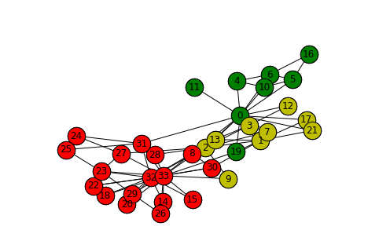

```python
pos=nx.spring_layout(Gn_karate)
nx.draw(Gn_karate,pos,with_labels=True, node_size = 500)

#必须将networkx中的节点编号转换成字符才能和igraph里面的节点对应上
community_list_s=community_list
for i in range(0,len(community_list)):
    community_list_s[i]=map(str, community_list[i])

#将不同社团中的节点绘制成不同的颜色
nx.draw_networkx_nodes(Gn_karate,pos,nodelist=community_list_s[0],node_size=500, node_color='g', with_labels=True)
nx.draw_networkx_nodes(Gn_karate,pos,nodelist=community_list_s[1], node_size=500, node_color='y', with_labels=True)
nx.draw_networkx_nodes(Gn_karate,pos,nodelist=community_list_s[2], node_size=500, node_color='r', with_labels=True)
```

```python
#计算社团划分对应模块度
membership=[]        #新建一个空列表，membership初始化
for i in range(0,len(Gn_karate)):
    membership.append(0)

# 根据社团划分对membership赋值
for i in range(0,len(community_list)):
    nodes=map(int, community_list[i])
    for j in nodes:
        membership[j]=i
print membership

#根据membership计算模块度
Q_modularity=ig.GraphBase.modularity(Gi_karate, membership)
print Q_modularity
```

[output not shown]

$$NMI\left( {X;Y} \right){\rm{ = }}\frac{{I\left( {X;Y} \right)}}{{\sqrt {H\left( X \right)H\left( Y \right)} }}$$

## 5.3 基于GN算法算法的社团检测

```python
h1=Gi_karate.community_edge_betweenness(clusters=None, directed=False, weights=None)   # GN算法社团检测
print h1
```

```
Dendrogram, 34 elements, 33 merges

2 28 27 24 25 31 26 14 15 18 20 22 8 30 23 29 32 33 9 0 1 3 13 7 21 19 17 12 11 5 6 16 4 10
| |  |  |  |  |  |  |  |  |  |  |  | |  |  |  |  |  | | | | |  | |  |  |  |  |  | | |  | |
| |  |  |  |  |  |  |  |  |  |  |  | |  |  |  `--'  | | | | |  | |  |  |  |  |  | | |  | |
| |  |  |  |  |  |  |  |  |  |  |  | |  |  |   |    | | | | |  | |  |  |  |  |  | | |  | |
| |  |  |  `--'  |  |  |  |  |  |  | |  |  `---'    | | | | |  | |  |  |  |  |  | | |  | |
| |  |  |   |    |  |  |  |  |  |  | |  |    |      | | | | |  | |  |  |  |  |  | | |  | |
`-'  |  `---'    |  |  |  |  |  |  | |  `----'      | | | `-'  | |  |  |  |  |  | `-'  `-'
 |   |    |      |  |  |  |  |  |  | |    |         | | |  |   | |  |  |  |  |  |  |    |
 |   |    |      |  |  |  |  |  |  | |    |         | | `--'   | |  |  |  |  |  `--'    |
 |   |    |      |  |  |  |  |  |  | |    |         | |  |     | |  |  |  |  |   |      |
 |   |    |      |  |  |  |  |  |  | |    |         | `--'     | |  |  |  |  |   |      |
 |   |    |      |  |  |  |  |  |  | |    |         |  |       | |  |  |  |  |   |      |
 |   |    |      |  |  |  |  |  |  | `----'         |  `-------' |  |  |  |  |   |      |
 |   |    |      |  |  |  |  |  |  |   |            |      |     |  |  |  |  |   |      |
 `---'    |      |  |  |  |  |  |  `---'            |      `-----'  |  |  |  |   |      |
   |      |      |  |  |  |  |  |    |              |         |     |  |  |  |   |      |
   |      |      |  |  |  |  |  `----'              |         `-----'  |  |  |   `------'
   |      |      |  |  |  |  |    |                 |            |     |  |  |      |
   |      |      |  |  |  |  `----'                 |            `-----'  |  |      |
   |      |      |  |  |  |    |                    |               |     |  |      |
   |      |      |  |  |  `----'                    |               |     |  |      |
   |      |      |  |  |    |                       |               |     |  |      |
   `------'      |  |  `----'                       |               |     |  |      |
      |          |  |    |                          |               |     |  |      |
      |          |  `----'                          |               `-----'  |      |
      |          |    |                             |                  |     |      |
      |          `----'                             |                  `-----'      |
      |            |                                |                     |         |
      `------------'                                |                     `---------'
            |                                       |                          |
            `---------------------------------------'                          |
                                |                                              |
                                `----------------------------------------------'
```

```python
community_list=list(h1.as_clustering())   # 对系统树图进行切割，按照Q值最大的标准
print community_list
```

```
[[0, 1, 3, 7, 11, 12, 13, 17, 19, 21], [2, 24, 25, 27, 28, 31], [4, 5, 6, 10, 16], [8, 14, 15, 18, 20, 22, 23, 26, 29, 30, 32, 33], [9]]
```

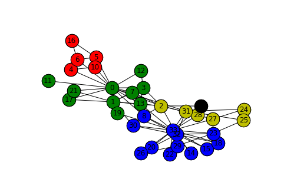

```python
pos=nx.spring_layout(Gn_karate)
nx.draw(Gn_karate,pos,with_labels=True, node_size = 500)

#必须将networkx中的节点编号转换成字符才能和igraph里面的节点对应上
community_list_s=community_list
for i in range(0,len(community_list)):
    community_list_s[i]=map(str, community_list[i])

#将不同社团中的节点绘制成不同的颜色
nx.draw_networkx_nodes(Gn_karate,pos,nodelist=community_list_s[0],node_size=500, node_color='g', with_labels=True)
nx.draw_networkx_nodes(Gn_karate,pos,nodelist=community_list_s[1], node_size=500, node_color='y', with_labels=True)
nx.draw_networkx_nodes(Gn_karate,pos,nodelist=community_list_s[2], node_size=500, node_color='r', with_labels=True)
nx.draw_networkx_nodes(Gn_karate,pos,nodelist=community_list_s[3], node_size=500, node_color='b', with_labels=True)
nx.draw_networkx_nodes(Gn_karate,pos,nodelist=community_list_s[4], node_size=500, node_color='k', with_labels=True)
```

```python
#计算社团划分对应模块度
membership=[]        #新建一个空列表，membership初始化
for i in range(0,len(Gn_karate)):
    membership.append(0)

# 根据社团划分对membership赋值
for i in range(0,len(community_list)):
    nodes=map(int, community_list[i])
    for j in nodes:
        membership[j]=i
print membership

#根据membership计算模块度
Q_modularity=ig.GraphBase.modularity(Gi_karate, membership)
print Q_modularity
```

```
[0, 0, 1, 0, 2, 2, 2, 0, 3, 4, 2, 0, 0, 0, 3, 3, 2, 0, 3, 0, 3, 0, 3, 3, 1, 1, 3, 1, 1, 3, 3, 1, 3, 3]
0.401298487837
```

## 5.4 基于标签传播算法的社团检测

```python
community_list1=Gi_karate.community_label_propagation(weights=None, initial=None, fixed=None)  # GN算法社团检测
print 'the modularity of this network is', community_list1.modularity
```

```
the modularity of this network is 0.132807363577
```

```python
community_list=[]
for item in community_list1:
    community_list.append(item)

print community_list
```

```
[[0, 1, 2, 3, 7, 8, 9, 11, 12, 13, 14, 15, 17, 18, 19, 20, 21, 22, 23, 24, 25, 26, 27, 28, 29, 30, 31, 32, 33], [4, 5, 6, 10, 16]]
```

[figure not shown]

```python
pos=nx.spring_layout(Gn_karate)
nx.draw(Gn_karate,pos,with_labels=True, node_size = 500)

#必须将networkx中的节点编号转换成字符才能和igraph里面的节点对应上
community_list_s=community_list
for i in range(0,len(community_list)):
    community_list_s[i]=map(str, community_list[i])

#将不同社团中的节点绘制成不同的颜色
for i in range(0,len(community_list_s)):
    if i%5 == 0:
        nx.draw_networkx_nodes(Gn_karate,pos,nodelist=community_list_s[0],node_size=500, node_color='g', with_labels=True)
    elif i%5 == 1:
        nx.draw_networkx_nodes(Gn_karate,pos,nodelist=community_list_s[1], node_size=500, node_color='y', with_labels=True)
    elif i%5 == 2:
        nx.draw_networkx_nodes(Gn_karate,pos,nodelist=community_list_s[2], node_size=500, node_color='b', with_labels=True)
    elif i%5 == 3:
        nx.draw_networkx_nodes(Gn_karate,pos,nodelist=community_list_s[3], node_size=500, node_color='r', with_labels=True)
    elif i%5 == 4:
        nx.draw_networkx_nodes(Gn_karate,pos,nodelist=community_list_s[4], node_size=500, node_color='m', with_labels=True)
```

## 5.5 基于community_leading_eigenvector算法的社团检测

```python
community_list1=Gi_karate.community_leading_eigenvector(clusters=None)
print 'the modularity of this network is', community_list1.modularity
```

```
the modularity of this network is 0.393408941486
```

```python
community_list=[]
for item in community_list1:
    community_list.append(item)

print community_list
```

```
[[0, 4, 5, 6, 10, 11, 16], [8, 9, 14, 15, 18, 20, 22, 26, 29, 30, 32, 33], [1, 2, 3, 7, 12, 13, 17, 19, 21], [23, 24, 25, 27, 28, 31]]
```

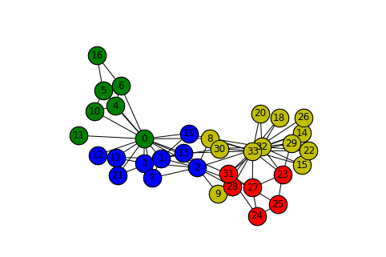

```python
pos=nx.spring_layout(Gn_karate)
nx.draw(Gn_karate,pos,with_labels=True, node_size = 500)

#必须将networkx中的节点编号转换成字符才能和igraph里面的节点对应上
community_list_s=community_list
for i in range(0,len(community_list)):
    community_list_s[i]=map(str, community_list[i])

#将不同社团中的节点绘制成不同的颜色
for i in range(0,len(community_list_s)):
    if i%5 == 0:
        nx.draw_networkx_nodes(Gn_karate,pos,nodelist=community_list_s[0],node_size=500, node_color='g', with_labels=True)
    elif i%5 == 1:
        nx.draw_networkx_nodes(Gn_karate,pos,nodelist=community_list_s[1], node_size=500, node_color='y', with_labels=True)
    elif i%5 == 2:
        nx.draw_networkx_nodes(Gn_karate,pos,nodelist=community_list_s[2], node_size=500, node_color='b', with_labels=True)
    elif i%5 == 3:
        nx.draw_networkx_nodes(Gn_karate,pos,nodelist=community_list_s[3], node_size=500, node_color='r', with_labels=True)
    elif i%5 == 4:
        nx.draw_networkx_nodes(Gn_karate,pos,nodelist=community_list_s[4], node_size=500, node_color='m', with_labels=True)
```

## 5.5 基于community_multilevel算法的社团检测

```python
community_list1=Gi_karate.community_multilevel(weights=None, return_levels=True)
```

[output not shown]

```python
community_list=[]
for item in community_list1:
    community_list.append(item)

print community_list
```

```
[<igraph.clustering.VertexClustering object at 0x11340b9d0>, <igraph.clustering.VertexClustering object at 0x11340b090>]
```

```python
Gi_karate.community_multilevel(weights=None, return_levels=True)
```

```
[<igraph.clustering.VertexClustering at 0x1132801d0>,
 <igraph.clustering.VertexClustering at 0x113280910>]
```

## 5.6 基于community_optimal_modularity算法的社团检测

```python
community_list1=Gi_karate.community_optimal_modularity(weights=None)
print 'the modularity of this network is', community_list1.modularity
```

```
the modularity of this network is 0.419789612097
```

```python
community_list=[]
for item in community_list1:
    community_list.append(item)

print community_list
```

```
[[0, 1, 2, 3, 7, 11, 12, 13, 17, 19, 21], [4, 5, 6, 10, 16], [8, 9, 14, 15, 18, 20, 22, 26, 29, 30, 32, 33], [23, 24, 25, 27, 28, 31]]
```

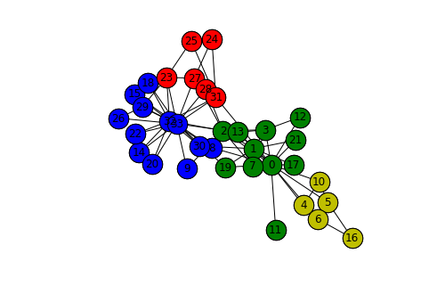

```python
pos=nx.spring_layout(Gn_karate)
nx.draw(Gn_karate,pos,with_labels=True, node_size = 500)

#必须将networkx中的节点编号转换成字符才能和igraph里面的节点对应上
community_list_s=community_list
for i in range(0,len(community_list)):
    community_list_s[i]=map(str, community_list[i])

#将不同社团中的节点绘制成不同的颜色
for i in range(0,len(community_list_s)):
    if i%5 == 0:
        nx.draw_networkx_nodes(Gn_karate,pos,nodelist=community_list_s[0],node_size=500, node_color='g', with_labels=True)
    elif i%5 == 1:
        nx.draw_networkx_nodes(Gn_karate,pos,nodelist=community_list_s[1], node_size=500, node_color='y', with_labels=True)
    elif i%5 == 2:
        nx.draw_networkx_nodes(Gn_karate,pos,nodelist=community_list_s[2], node_size=500, node_color='b', with_labels=True)
    elif i%5 == 3:
        nx.draw_networkx_nodes(Gn_karate,pos,nodelist=community_list_s[3], node_size=500, node_color='r', with_labels=True)
    elif i%5 == 4:
        nx.draw_networkx_nodes(Gn_karate,pos,nodelist=community_list_s[4], node_size=500, node_color='m', with_labels=True)
```

## 5.7 基于community_walktrap算法的社团检测

```python
h1=Gi_karate.community_walktrap(weights=None, steps=1000)
print h1
```

```
Dendrogram, 34 elements, 33 merges

21 0 6 11 12 3 17 1 13 19 16 7 10 4 5 32 29 2 30 25 24 27 33 8 20 28 26 31 14 15 18 22 9 23
|  | | |  |  | |  | |  |  |  | |  | | |  |  | |  |  |  |  |  | |  |  |  |  |  |  |  |  | |
`--' | |  |  | |  | |  |  |  | |  | | `--'  | |  |  |  |  `--' |  |  |  |  |  |  |  |  | |
 |   | |  |  | |  | |  |  |  | |  | |  |    | |  |  |  |   |   |  |  |  |  |  |  |  |  | |
 `---' |  |  | |  | |  |  |  | |  | |  |    | |  `--'  |   `---'  |  |  |  |  |  |  |  | |
   |   |  |  | |  | |  |  |  | |  | |  |    | |   |    |     |    |  |  |  |  |  |  |  | |
   |   |  `--' `--' |  |  |  | |  | |  `----' |   `----'     |    |  |  |  |  |  |  |  | |
   |   |   |    |   |  |  |  | |  | |    |    |     |        |    |  |  |  |  |  |  |  | |
   `---'   `----'   |  |  |  | |  | |    |    |     |        |    |  |  |  |  |  |  |  | |
     |       |      |  |  |  | |  | |    |    |     |        |    |  |  |  |  |  |  |  | |
     `-------'      |  |  |  | |  | |    `----'     `--------'    |  |  |  |  |  |  |  | |
         |          |  |  |  | |  | |      |            |         |  |  |  |  |  |  |  | |
         `----------'  |  |  | `--' |      `------------'         |  |  |  |  |  |  |  | |
              |        |  |  |  |   |            |                |  |  |  |  |  |  |  | |
              `--------'  |  |  `---'            `----------------'  |  |  |  |  |  |  | |
                  |       |  |    |                      |           |  |  |  |  |  |  | |
                  `-------'  |    |                      `-----------'  |  |  |  |  |  | |
                      |      |    |                            |        |  |  |  |  |  | |
                      |      |    |                            `--------'  |  |  |  |  | |
                      |      |    |                                |       |  |  |  |  | |
                      |      |    |                                `-------'  |  |  |  | |
                      |      |    |                                    |      |  |  |  | |
                      |      |    |                                    `------'  |  |  | |
                      |      |    |                                       |      |  |  | |
                      |      |    |                                       `------'  |  | |
                      |      |    |                                          |      |  | |
                      |      |    |                                          `------'  | |
                      |      |    |                                             |      | |
                      |      |    |                                             `------' |
                      |      |    |                                                |     |
                      `------'    |                                                `-----'
                         |        |                                                   |
                         `--------'                                                   |
                             |                                                        |
                             `--------------------------------------------------------'
```

```python
community_list=list(h1.as_clustering())   # 对系统树图进行切割，按照Q值最大的标准
print community_list
```

```
[[0, 1, 3, 4, 5, 6, 7, 10, 11, 12, 13, 16, 17, 19, 21], [2, 8, 9, 14, 15, 18, 20, 22, 23, 24, 25, 26, 27, 28, 29, 30, 31, 32, 33]]
```

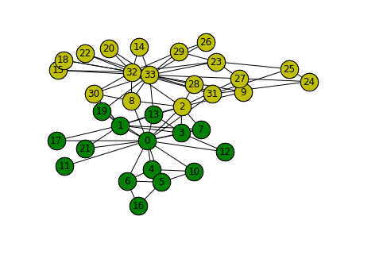

```python
pos=nx.spring_layout(Gn_karate)
nx.draw(Gn_karate,pos,with_labels=True, node_size = 500)

#必须将networkx中的节点编号转换成字符才能和igraph里面的节点对应上
community_list_s=community_list
for i in range(0,len(community_list)):
    community_list_s[i]=map(str, community_list[i])

#将不同社团中的节点绘制成不同的颜色
for i in range(0,len(community_list_s)):
    if i%5 == 0:
        nx.draw_networkx_nodes(Gn_karate,pos,nodelist=community_list_s[0],node_size=500, node_color='g', with_labels=True)
    elif i%5 == 1:
        nx.draw_networkx_nodes(Gn_karate,pos,nodelist=community_list_s[1], node_size=500, node_color='y', with_labels=True)
    elif i%5 == 2:
        nx.draw_networkx_nodes(Gn_karate,pos,nodelist=community_list_s[2], node_size=500, node_color='b', with_labels=True)
    elif i%5 == 3:
        nx.draw_networkx_nodes(Gn_karate,pos,nodelist=community_list_s[3], node_size=500, node_color='r', with_labels=True)
    elif i%5 == 4:
        nx.draw_networkx_nodes(Gn_karate,pos,nodelist=community_list_s[4], node_size=500, node_color='m', with_labels=True)
```

```python
#计算社团划分对应模块度
membership=[]        #新建一个空列表，membership初始化
for i in range(0,len(Gn_karate)):
    membership.append(0)

# 根据社团划分对membership赋值
for i in range(0,len(community_list)):
    nodes=map(int, community_list[i])
    for j in nodes:
        membership[j]=i
print membership

#根据membership计算模块度
Q_modularity=ig.GraphBase.modularity(Gi_karate, membership)
print Q_modularity
```

```
[0, 0, 1, 0, 0, 0, 0, 0, 1, 1, 0, 0, 0, 0, 1, 1, 0, 0, 1, 0, 1, 0, 1, 1, 1, 1, 1, 1, 1, 1, 1, 1, 1, 1]
0.359960552268
```

## 5.8 基于community_spinglass算法的社团检测

```python
community_list1=Gi_karate.community_spinglass(weights=None,spins=25,parupdate=False,start_temp=1,stop_temp=0.01,cool_fact=0.99,update_rule="config",gamma=1,implementation="orig")
print 'the modularity of this network is', community_list1.modularity
```

```
the modularity of this network is 0.418803418803
```

```python
community_list=[]
for item in community_list1:
    community_list.append(item)

print community_list
```

```
[[23, 24, 25, 27, 28, 31], [0, 1, 2, 3, 7, 9, 11, 12, 13, 17, 19, 21], [4, 5, 6, 10, 16], [8, 14, 15, 18, 20, 22, 26, 29, 30, 32, 33]]
```

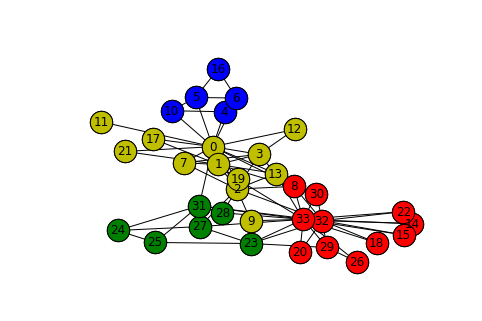

```python
pos=nx.spring_layout(Gn_karate)
nx.draw(Gn_karate,pos,with_labels=True, node_size = 500)

#必须将networkx中的节点编号转换成字符才能和igraph里面的节点对应上
community_list_s=community_list
for i in range(0,len(community_list)):
    community_list_s[i]=map(str, community_list[i])

#将不同社团中的节点绘制成不同的颜色
for i in range(0,len(community_list_s)):
    if i%5 == 0:
        nx.draw_networkx_nodes(Gn_karate,pos,nodelist=community_list_s[0],node_size=500, node_color='g', with_labels=True)
    elif i%5 == 1:
        nx.draw_networkx_nodes(Gn_karate,pos,nodelist=community_list_s[1], node_size=500, node_color='y', with_labels=True)
    elif i%5 == 2:
        nx.draw_networkx_nodes(Gn_karate,pos,nodelist=community_list_s[2], node_size=500, node_color='b', with_labels=True)
    elif i%5 == 3:
        nx.draw_networkx_nodes(Gn_karate,pos,nodelist=community_list_s[3], node_size=500, node_color='r', with_labels=True)
    elif i%5 == 4:
        nx.draw_networkx_nodes(Gn_karate,pos,nodelist=community_list_s[4], node_size=500, node_color='m', with_labels=True)
```

## 5.9 基于community_infomap算法的社团检测

```python
community_list1=Gi_karate.community_infomap()
print 'the modularity of this network is', community_list1.modularity
```

```
the modularity of this network is 0.402038132807
```

```python
community_list=[]
for item in community_list1:
    community_list.append(item)

print community_list
```

```
[[8, 14, 15, 18, 20, 22, 23, 24, 25, 26, 27, 28, 29, 30, 31, 32, 33], [0, 1, 2, 3, 7, 9, 11, 12, 13, 17, 19, 21], [4, 5, 6, 10, 16]]
```

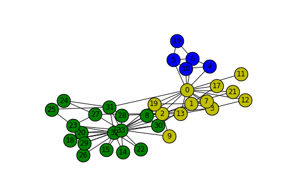

```python
pos=nx.spring_layout(Gn_karate)
nx.draw(Gn_karate,pos,with_labels=True, node_size = 500)

#必须将networkx中的节点编号转换成字符才能和igraph里面的节点对应上
community_list_s=community_list
for i in range(0,len(community_list)):
    community_list_s[i]=map(str, community_list[i])

#将不同社团中的节点绘制成不同的颜色
for i in range(0,len(community_list_s)):
    if i%5 == 0:
        nx.draw_networkx_nodes(Gn_karate,pos,nodelist=community_list_s[0],node_size=500, node_color='g', with_labels=True)
    elif i%5 == 1:
        nx.draw_networkx_nodes(Gn_karate,pos,nodelist=community_list_s[1], node_size=500, node_color='y', with_labels=True)
    elif i%5 == 2:
        nx.draw_networkx_nodes(Gn_karate,pos,nodelist=community_list_s[2], node_size=500, node_color='b', with_labels=True)
    elif i%5 == 3:
        nx.draw_networkx_nodes(Gn_karate,pos,nodelist=community_list_s[3], node_size=500, node_color='r', with_labels=True)
    elif i%5 == 4:
        nx.draw_networkx_nodes(Gn_karate,pos,nodelist=community_list_s[4], node_size=500, node_color='m', with_labels=True)
```

## 5.10 比较不同社交检测算法之间的差别

(1) compare_communities(comm1, comm2, method='vi', remove_none=False) Compares two community structures using various distance measures.  
(2) split_join_distance(comm1, comm2, remove_none=False) Calculates the split-join distance between two community structures.

## 5.11 尚未完成的其他部分（许）

snap库中进行社团划分的方法

1) 对训练集中社交圈子数据的分析，主要包括： （1） 每个人的社交圈子数量 （2） 每个社交圈子的成员数量 （3） 被分圈好友占所有好友的百分比，每个用户好友数量 （4） 被分在多个社交圈子的成员次数占所有成员的百分比 （5） 是否有大圈子中有小圈子的情形（现将圈子分为学校，然后再分出班级来） （6） 被分圈成员在网络结构上的偏好性（是不是朋友多的被分圈了） （7） 社交圈子和社交网络结构尤其是社团检测算法的契合程度（定性）